# Untitled

Juan Carlos Villaseñor-Derbez

3 de mayo de 2018

# Questions

The three main questions are:

- Where were MPAs implemented in 2012 - 2018, and hos does this relate to fishing effort and a lag in protection (by counry / by marine ecoregion)?
- What are areas of opportunity in terms of an MPA Kobe plot?
- What has happened to fishing effort when MPA is put in place? Is it re-distributed or reduced?

```r
## Clear the environment
rm(list = ls())

# Load packages
suppressPackageStartupMessages({
  library(janitor)
  library(here)
  library(lwgeom)
  library(sf)
  library(tidyverse)
})

# Source functions
source(here("scripts","sfc_as_cols.R"))
```

# Calculate fishing effort by MEOW - country EEZ partition

Some EEZ conain more than one MEOW, and some MEOW contain more than one EEZ or are split into various EEZs. I want to calculate the total fishing effort of for each pocket of EEZ and MEOW, which means I need to use both EEZ and MEOW shapefiles and break them into smaller pieces.

I will be working with spatial data, so I want to make sure I have everything in the same projection

```r
proj <- "+proj=longlat +datum=WGS84 +no_defs +ellps=WGS84 +towgs84=0,0,0"
```

First I read in the fishing effort

```r
mean_binned_fishing <- read.csv(here("data", "mean_yearly_fishing_effort.csv")) %>%
  filter(mean_fishing_hours > 0)
```

And the coastline of the world

```r
world_coastline <- st_read(dsn = here("data", "spatial"),
                           layer = "world_coastline",
                           quiet = T,
                           stringsAsFactors = F)
```

Now the MEOW data

```r
meow <- read_sf(dsn = here("raw_data","spatial","MEOW"),
                layer = "meow_ecos",
                quiet = T,
                stringsAsFactors = F) %>%
  janitor::clean_names() %>%
  st_transform(crs = proj) %>%
  mutate(area = st_area(.))
```

And finally I read in the EEZ data

```r
EEZ <- read_sf(dsn = here("raw_data","spatial","World_EEZ_v10_20180221"),
               layer = "eez_v10",
               quiet = T,
               stringsAsFactors = F) %>%
  clean_names() %>%
  st_simplify(dTolerance = 0.1)%>%
  st_transform(crs = proj)
```

And now I visualize them all together

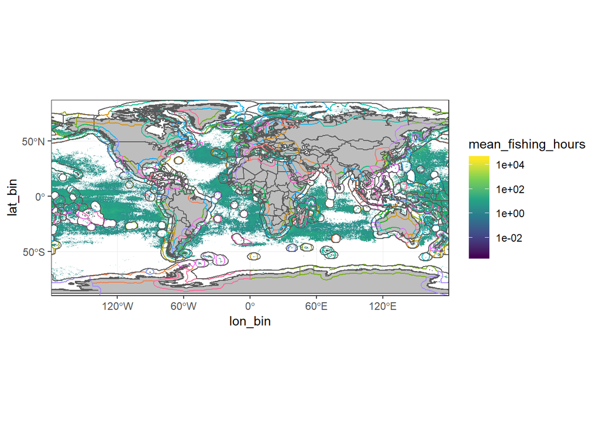

```r
p1 <- ggplot(mean_binned_fishing) +
  geom_raster(aes(x = lon_bin, y = lat_bin, fill = mean_fishing_hours), interpolate = T) +
  geom_sf(data = world_coastline, fill = "gray", show.legend = F) +
  geom_sf(data = meow, aes(color = ecoregion), fill = "transparent", show.legend = F) +
  geom_sf(data = EEZ, fill = "transparent", show.legend = F) +
  theme_bw() +
  scale_fill_viridis_c(trans = "log10") +
  scale_y_continuous(expand = c(0, 0)) +
  scale_x_continuous(expand = c(0, 0))

p1
```

Let’s do a closeup to US-Mexico to view cases where EEZs and MEOW have different extents. For example, the Southern Californian Bight Marine Ecoregion is split for Southern California and The northern part of Baja. It also takes some part in land. I want to break each “color” into pieces defined by the EEZ shape.

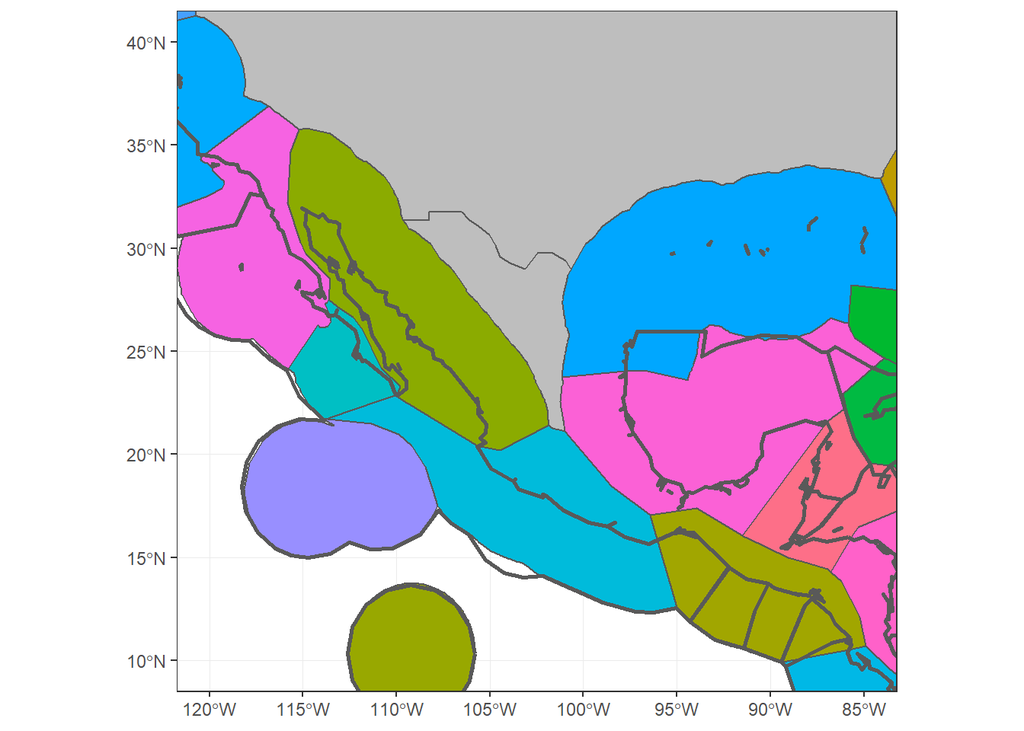

```r
ggplot() +
  geom_sf(data = world_coastline, fill = "gray", show.legend = F) +
  geom_sf(data = meow, aes(fill = ecoregion), show.legend = F) +
  geom_sf(data = EEZ, fill = "transparent", show.legend = F, size = 1) +
  theme_bw() +
  xlim(-120, -85) +
  ylim(10, 40)
```

Let’s try an example and see how to get it. First, select a couple of countries, filter from EEZs to only keep the ones present there. Then we intersect with meow to keep the part where they overlap.

```r
countries <- c("MEX", "GTM", "SLV", "HND", "NIC")

eez_meow <- EEZ %>%
  dplyr::select(iso_ter1) %>%
  filter(iso_ter1 %in% countries) %>%
  st_intersection(meow) %>%
  select(iso3 = iso_ter1, realm, province, ecoregion) %>%
  mutate(eez_ecoregion = paste(iso3, ecoregion),
         area = st_area(.)) %>%
  arrange(iso3, realm, province, ecoregion, eez_ecoregion, area)
```

```
## although coordinates are longitude/latitude, st_intersection assumes that they are planar
```

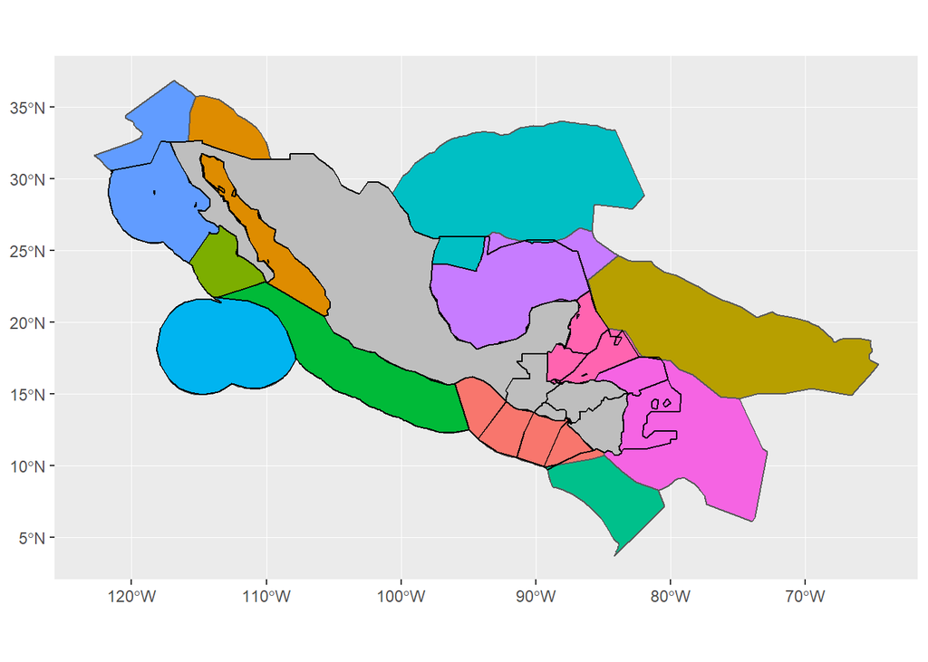

```r
temp_meow <- meow %>%
  filter(ecoregion %in% eez_meow$ecoregion)

ggplot() +
  geom_sf(data = temp_meow, aes(fill = ecoregion), show.legend = F) +
  geom_sf(data = eez_meow, fill = "transparent", color = "black") +
  geom_sf(data = filter(world_coastline, iso3 %in% countries), fill = "gray", color = "black")
```

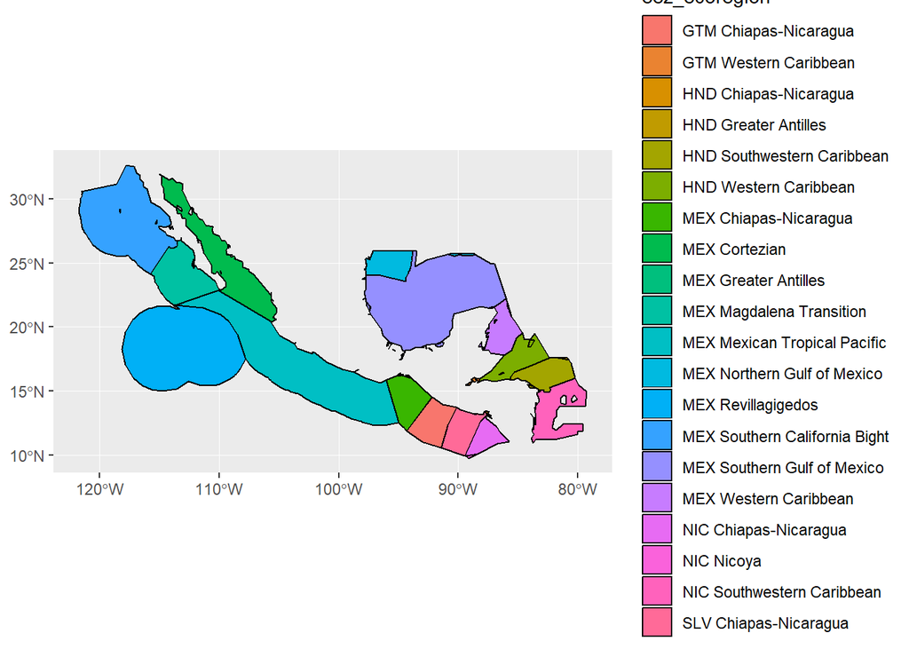

```r
ggplot(eez_meow) +
  geom_sf(aes(fill = eez_ecoregion), color = "black")
```

I then want to have the ammount of fishing effort in every one of this polygons.

```r
masked_mean_binned_fishing <- mean_binned_fishing %>%
  filter(between(lon_bin, -120, -80),
         between(lat_bin, 10, 35)) %>%
  st_as_sf(coords = c("lon_bin", "lat_bin"), crs = proj) %>%
  st_intersection(y = eez_meow) %>%
  sfc_as_cols(names = c("lon", "lat")) %>%
  st_set_geometry(NULL) %>%
  group_by(eez_ecoregion) %>%
  summarize(hours = sum(mean_fishing_hours)) %>%
  ungroup()
```

```
## although coordinates are longitude/latitude, st_intersection assumes that they are planar
```

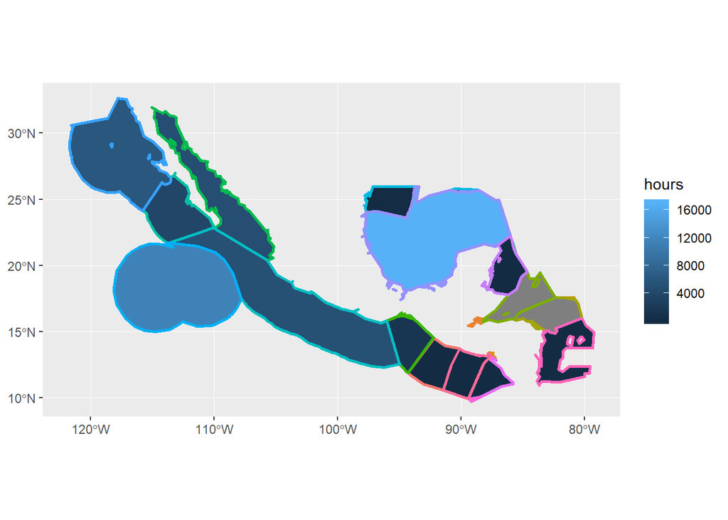

```r
eez_meow %>%
  left_join(masked_mean_binned_fishing, by = "eez_ecoregion") %>%
  mutate(norm_hours = hours / area) %>%
  ggplot() +
  geom_sf(aes(color = eez_ecoregion, fill = hours), size = 1) +
  guides(color = F)
```

Now lets do it for all the EEZs and all the MEOWs

```r
eez_meow <- EEZ %>%
  dplyr::select(iso_ter1) %>%
  st_intersection(meow) %>%
  select(iso3 = iso_ter1, realm, province, ecoregion) %>%
  mutate(eez_ecoregion = paste(iso3, ecoregion),
         area = st_area(.),
         area = as.numeric(area)/1e6) %>%
  arrange(iso3, realm, province, ecoregion, eez_ecoregion, area)
```

```
## although coordinates are longitude/latitude, st_intersection assumes that they are planar
```

Masking all fishing effort takes a while…

```r
masked_mean_binned_fishing <- mean_binned_fishing %>%
  st_as_sf(coords = c("lon_bin", "lat_bin"), crs = proj) %>%
  st_intersection(y = eez_meow) %>%
  sfc_as_cols(names = c("lon", "lat")) %>%
  st_set_geometry(NULL) %>%
  group_by(eez_ecoregion) %>%
  summarize(hours = sum(mean_fishing_hours)) %>%
  ungroup()
```

```
## although coordinates are longitude/latitude, st_intersection assumes that they are planar
```

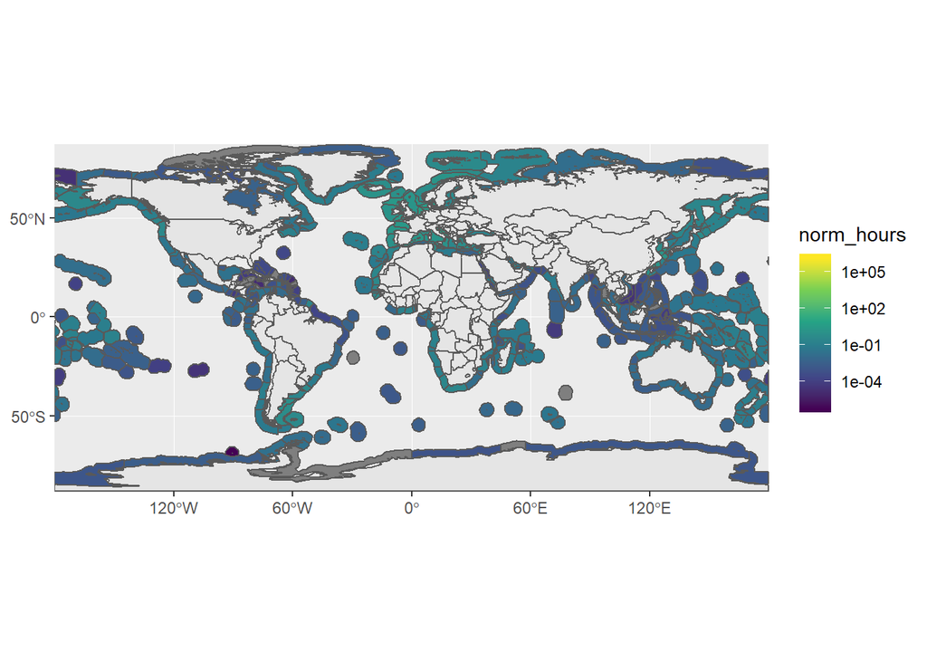

```r
fishing_by_eez_meow <- eez_meow %>%
  left_join(masked_mean_binned_fishing, by = "eez_ecoregion") %>%
  mutate(area = area) %>%
  mutate(norm_hours = hours / area)

ggplot() +
  geom_sf(data = world_coastline) +
  geom_sf(data = fishing_by_eez_meow, aes(fill = norm_hours)) +
  guides(color = F) +
  scale_fill_viridis_c(trans = "log10") +
  scale_y_continuous(expand = c(0, 0)) +
  scale_x_continuous(expand = c(0, 0))
```

# Calculate MPA coverage by MEOW - country EEZ partition

```r
# Read the points shapefile
mpas_points <- read_sf(dsn = here("raw_data","spatial","WDPA_Mar2018"),
                layer = "WDPA_Mar2018_marine-shapefile-points",
                quiet = T,
                stringsAsFactors = F) %>%
  janitor::clean_names() %>%
  st_transform(crs = proj)

# Read the polygon shapefile
mpas_poly <- read_sf(dsn = here("raw_data","spatial","WDPA_Mar2018"),
                layer = "WDPA_Mar2018_marine-shapefile-polygons",
                quiet = T,
                stringsAsFactors = F) %>%
  st_make_valid() %>%
  st_centroid() %>%
  janitor::clean_names() %>%
  st_transform(crs = proj)
```

I need to join the plygons (now points) and points to have a single `sf` object with all MPAs

```r
all_mpas <- mpas_poly %>%
  select(-c(gis_area, gis_m_area)) %>%
  rbind(mpas_points) %>%
  filter(!iucn_cat %in% c("Not Applicable", "Not Reported", "Not Assigned"))
```

Let’s visualize this

```r
all_mpas_dataframe <- all_mpas %>%
  st_cast(to = "MULTIPOINT") %>%
  sfc_as_cols(names = c("lon","lat")) %>%
  select(-V1) %>%
  as.tibble() %>%
  filter(rep_m_area > 0)

p <- ggplot() +
  geom_sf(data = world_coastline, fill = "gray") +
  geom_sf(data = eez_meow) +
  geom_point(data = all_mpas_dataframe, aes(x = lon, y = lat, color = iucn_cat), size = 1, alpha = 0.8) +
  scale_color_brewer(palette = "Paired") +
  theme(legend.position = "bottom",
        panel.grid.major = element_line(colour = "transparent"))
```

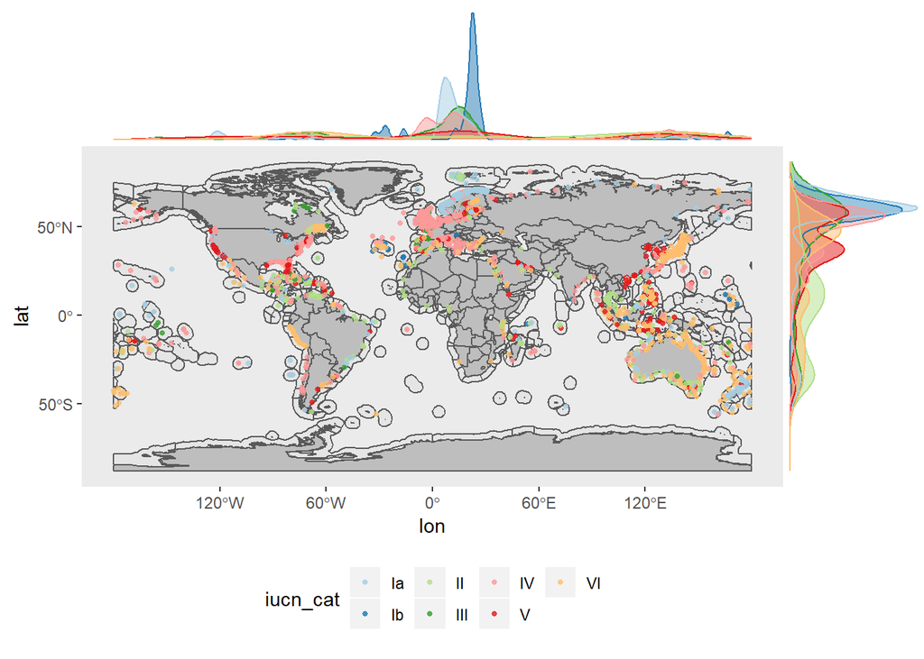

```r
pm <- ggExtra::ggMarginal(p, groupFill = TRUE, groupColour = T)

grid::grid.newpage()
grid::grid.draw(pm)
```

```r
masked_mpas <- all_mpas  %>%
  st_intersection(y = eez_meow) %>%
  sfc_as_cols(names = c("lon", "lat")) %>%
  st_set_geometry(NULL) %>%
  group_by(eez_ecoregion) %>%
  summarize(protected_area = sum(rep_area)) %>%
  ungroup()
```

```
## although coordinates are longitude/latitude, st_intersection assumes that they are planar
```

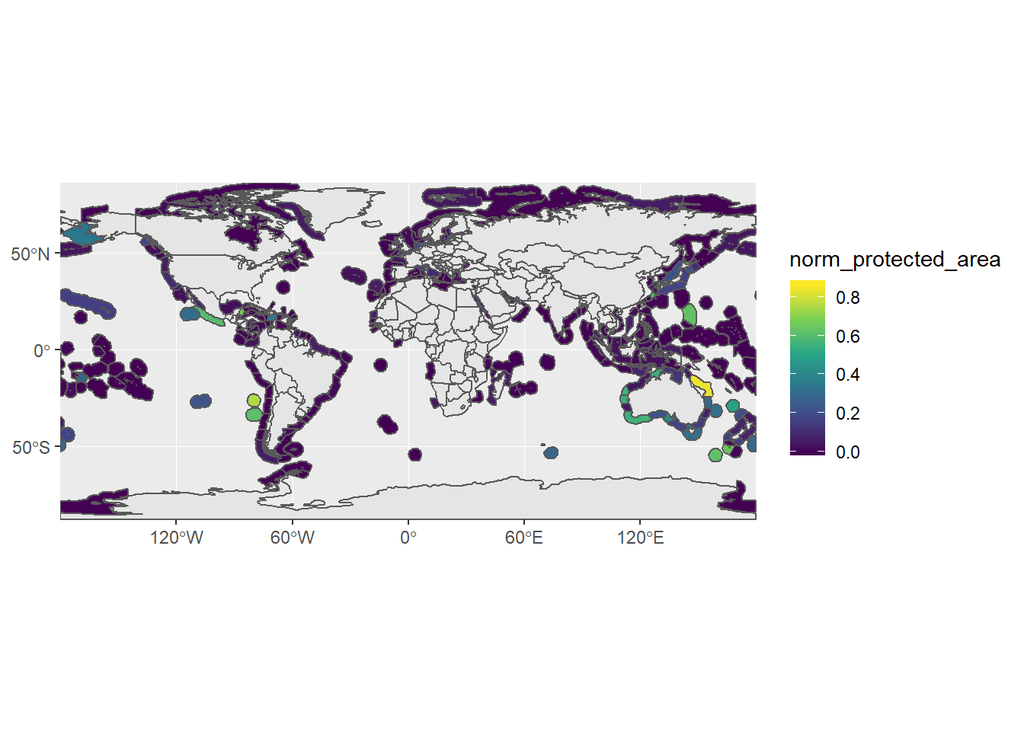

```r
mpas_by_eez_meow <- eez_meow %>%
  left_join(masked_mpas, by = "eez_ecoregion") %>%
  mutate(norm_protected_area = protected_area / area) %>%
  dplyr::filter(!is.na(norm_protected_area),
                norm_protected_area <= 1)

ggplot() +
  geom_sf(data = world_coastline) +
  geom_sf(data = mpas_by_eez_meow, aes(fill = norm_protected_area)) +
  guides(color = F) +
  scale_fill_viridis_c() +
  scale_y_continuous(expand = c(0, 0)) +
  scale_x_continuous(expand = c(0, 0))
```

La grafica de arriba esta mal. Tuve que fitlrar los datos normalizados < 1 para quitar los errores. Los errores casi seguro son causados por tener un centroide de una AMP que es muy grande, pero el ccentroide cae en un pedacito de una eez-meow recortada.

Voy a tratar de hacer lo mismo, pero agrupando por realm

# Repeat exercise by realm

## Base units

Get a shapefile of only realms

```r
realms <- meow %>%
  group_by(realm) %>%
  summarize(area = sum(area)) %>%
  ungroup()
```

Crop EEZs into realms

```r
eez_realm <- EEZ %>%
  dplyr::select(iso_ter1) %>%
  st_intersection(realms) %>%
  select(iso3 = iso_ter1, realm) %>%
  mutate(eez_realm = paste(iso3, realm),
         area = st_area(.),
         area = as.numeric(area)/1e6) %>%
  arrange(iso3, realm, eez_realm, area)
```

```
## although coordinates are longitude/latitude, st_intersection assumes that they are planar
```

## Fishing

Get fishing effort by eez_realm

```r
masked_mean_binned_fishing_realm <- mean_binned_fishing %>%
  st_as_sf(coords = c("lon_bin", "lat_bin"), crs = proj) %>%
  st_intersection(y = eez_realm) %>%
  sfc_as_cols(names = c("lon", "lat")) %>%
  st_set_geometry(NULL) %>%
  group_by(eez_realm) %>%
  summarize(hours = sum(mean_fishing_hours)) %>%
  ungroup()
```

```
## although coordinates are longitude/latitude, st_intersection assumes that they are planar
```

Join to the data and plot

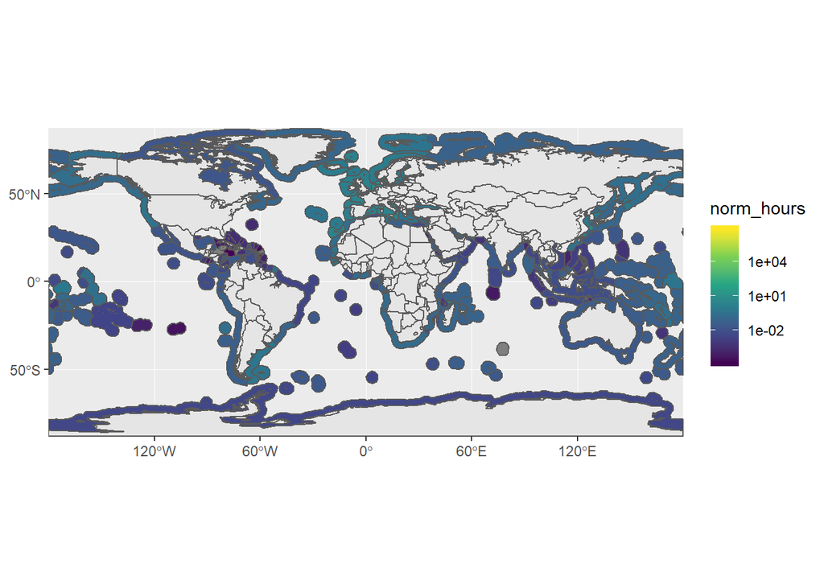

```r
fishing_by_eez_realm <- eez_realm %>%
  left_join(masked_mean_binned_fishing_realm, by = "eez_realm") %>%
  mutate(area = area) %>%
  mutate(norm_hours = hours / area)

ggplot() +
  geom_sf(data = world_coastline) +
  geom_sf(data = fishing_by_eez_realm, aes(fill = norm_hours)) +
  guides(color = F) +
  scale_fill_viridis_c(trans = "log10") +
  scale_y_continuous(expand = c(0, 0)) +
  scale_x_continuous(expand = c(0, 0))
```

## MPAS

Get mpas in each realm

```r
masked_mpas_realm <- all_mpas  %>%
  st_intersection(y = eez_realm) %>%
  sfc_as_cols(names = c("lon", "lat")) %>%
  st_set_geometry(NULL) %>%
  group_by(eez_realm) %>%
  summarize(protected_area = sum(rep_area)) %>%
  ungroup()
```

```
## although coordinates are longitude/latitude, st_intersection assumes that they are planar
```

Join to the data and plot

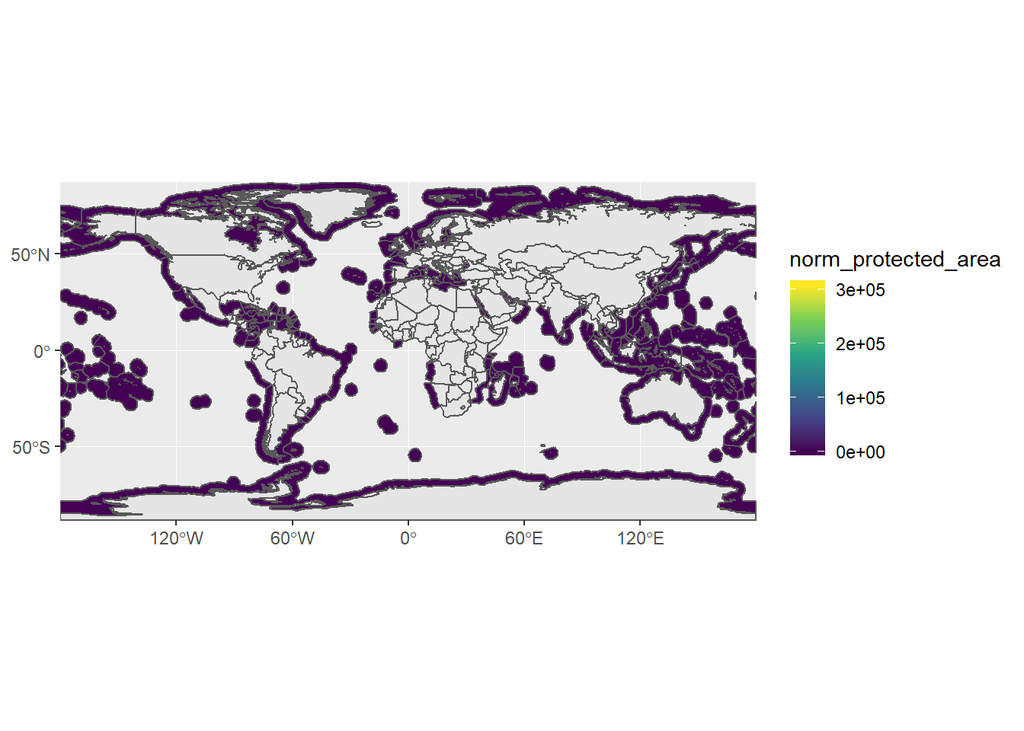

```r
mpas_by_eez_realm <- eez_realm %>%
  left_join(masked_mpas_realm, by = "eez_realm") %>%
  mutate(norm_protected_area = protected_area / area) %>%
  dplyr::filter(!is.na(norm_protected_area))

ggplot() +
  geom_sf(data = world_coastline) +
  geom_sf(data = mpas_by_eez_realm, aes(fill = norm_protected_area)) +
  guides(color = F) +
  scale_fill_viridis_c() +
  scale_y_continuous(expand = c(0, 0)) +
  scale_x_continuous(expand = c(0, 0))
```

Hay que revisar que todas las AMPS esten en ambos sets de datos y si no, juntalros

Tambien hay que ver por que chingados porcentage de area protegida da tan alto

## Ejemplo de como se pueden perder areas

En este caso, el centroide de la AMP de COK cae fuera de cualquier MEOW, y el punto se pierde

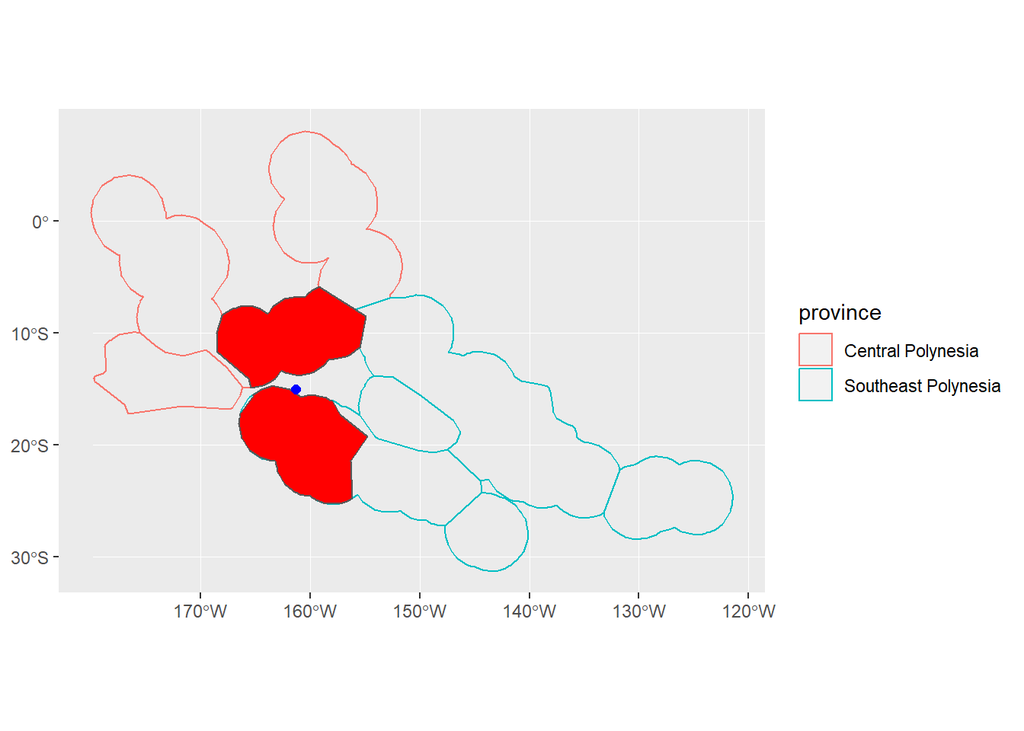

```r
cook_eez <- filter(EEZ, iso_ter1 == "COK")
cook_eez_meow <- filter(eez_realm, iso3 == "COK")
realm <- filter(meow, realm == "Eastern Indo-Pacific")
province <- filter(meow, province %in% c("Central Polynesia", "Southeast Polynesia"))
cook_MPA <- mpas_poly %>%
  filter(wdpaid == 555624907)

ggplot() +
  geom_sf(data = province, fill = "transparent", aes(color = province)) +
  geom_sf(data = cook_eez_meow, fill = "red") +
  geom_sf(data = cook_MPA, color = "blue", size = 2, fill = "transparent")
```

Cosas por hacer:

- Ver cuales AMPs estan quedando fuera, y la forma de incorporarlas a su MEOW / REALM respectivo
- Identificar AMPs que dan proporciones > 1 y ver como resolverlas